# Client Report - The War with Star Wars

## QUESTION 2

**Filter the dataset to 835 respondents that have seen at least one film** (Hint: Don’t use the column `Have you seen any of the 6 films in the Star Wars franchise?`) Not much to show here by way of output. Print the shape (i.e. number of rows and number of columns) of the filtered dataset.

```python
# Include and execute your code here

# # df2 = df[df['seen_any'] == "Yes"]
# # df2.head()

# seen_cols = ['seen_1', 'seen_2', 'seen_3', 'seen_4', 'seen_5', 'seen_6']

# seen_any = df[seen_cols].apply(lambda x: x == 'Yes').any(axis=1)

# df_seen.shape
# print(f"I could not get this one to work! It is showing this but i don't think its right {df_seen = df[seen_any]}")


# np select
####################################################

# # Find the columns that start with "seen_" — these are the ones indicating whether a person has seen a film
# seen_cols = [col for col in df.columns if col.startswith('seen_')]

# # Check which respondents have "Yes" in at least one of those columns
# has_seen = df[seen_cols].eq('Yes').any(axis=1)

# # Filter the dataset
# df_seen = df[has_seen]

# # Display the number of respondents and columns
# print(f"Filtered dataset shape: {df_seen.shape}")
####################################################
```

```python
seen_cols = ['seen_I', 'seen_II', 'seen_III', 'seen_IV', 'seen_V', 'seen_VI']

# Filter rows where any of the seen columns is NOT null
has_seen = df[seen_cols].notna().any(axis=1)

df_seen = df[has_seen]

print(f"Filtered dataset shape: {df_seen.shape}")
```

```
Filtered dataset shape: (835, 38)
```

## QUESTION 3

**Validate that the data provided on GitHub lines up with the article by recreating 2 of the visuals from the article.** These visuals should be similar, but don’t have to be exact. They need to be close enough that we can validate that the value s in the dataset match the graphs in the chart. Though their charts were built using a different plotting software, the more you push yourself for an exact replica, the more you will learn. Spend at least a couple of hours on this.

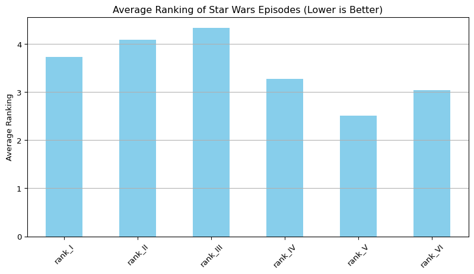

```python
import matplotlib.pyplot as plt

# Columns with rank data
rank_cols = [col for col in df_seen.columns if col.startswith('rank_')]

# Compute the average rank (lower = better)
rank_means = df_seen[rank_cols].apply(pd.to_numeric, errors='coerce').mean()

# Plot
plt.figure(figsize=(10, 5))
rank_means.plot(kind='bar', color='skyblue')
plt.title("Average Ranking of Star Wars Episodes (Lower is Better)")
plt.ylabel("Average Ranking")
plt.xticks(rotation=45)
plt.grid(axis='y')
plt.show()
```

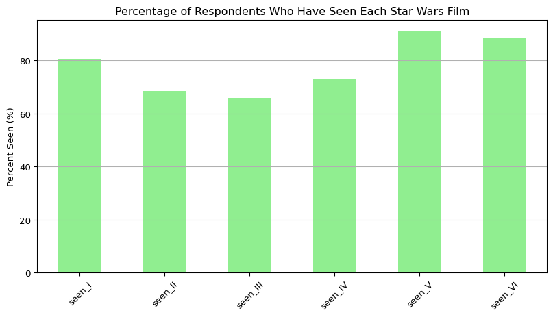

```python
seen_cols = ['seen_I', 'seen_II', 'seen_III', 'seen_IV', 'seen_V', 'seen_VI']

# Calculate percent seen by checking non-null values in each column
seen_percent = df_seen[seen_cols].notna().mean() * 100

# Plot
plt.figure(figsize=(10, 5))
seen_percent.plot(kind='bar', color='lightgreen')
plt.title("Percentage of Respondents Who Have Seen Each Star Wars Film")
plt.ylabel("Percent Seen (%)")
plt.xticks(rotation=45)
plt.grid(axis='y')
plt.show()
```